# Comparisons of Fst computations

`assigner`, `diveRsity`, `GenoDive`, `hierfstat`, `SNPRelate`, `stAMPP`, `strataG`, `VCFtools.`

Thierry Gosselin

2019-05-09

# Prepare your R session

```r
rm(list = ls()) # clean workspace
# install required packages
if (!require("remotes")) install.packages("remotes")
if (!require("assigner")) remotes::install_github("thierrygosselin/assigner")
if (!require("diveRsity")) install.packages("diveRsity")
if (!require("hierfstat")) install.packages("hierfstat")
if (!require("StAMPP")) install.packages("StAMPP")
if (!require("strataG")) install.packages("strataG")
if (!require("SNPRelate")) {
  if(!require("BiocManager")) install.packages("BiocManager")
  BiocManager::install("SNPRelate")
}
if (!require("ggcorrplot")) install.packages("ggcorrplot")
```

For macOS: [GenoDive](http://www.bentleydrummer.nl/software/software/GenoDive.html).

VCFtools: [install instructions](https://vcftools.github.io) or [here](https://gbs-cloud-tutorial.readthedocs.io/en/latest/07_start_from_new_image.html#install-gbs-radseq-software-time-required-30min)

**Versions of packages and software:**

```r
# Check packages versions
packageVersion('assigner') # 0.5.6.
packageVersion('diveRsity') # 1.9.90
packageVersion('hierfstat') # 0.4.22
packageVersion('stAMPP') # 1.5.1
packageVersion('strataG') # 2.0.2
packageVersion('SNPRelate') # 1.18.0
#GenoDive: 2.27
# VCFtools.: 0.1.17
```

Put this **Rmd notebook** in the same directory as the data or use `setwd("/YOUR/NEW/PATH/HERE/")`, to change the working directory.

# Goal of this exercise

Let’s see how `assigner's` Fst calculations (using Weir and Cockerham, 1984) compares with alternatives. To make differences and bottlenecks really stand out we will use a RADseq dataset with **thousands of markers**.

# Datasets

## Empirical dataset

We’re going to use the unfiltered vcf sunflower dataset from Owens et al. 2016, kindly provided by Gregory Owens. This dataset as missing data.

Owens GL, Baute GJ, Rieseberg LH. Revisiting a classic case of introgression: hybridization and gene flow in Californian sunflowers. Abbott RJ, Barton NH, Good JM, editors. Molecular Ecology. 2016;25: 2630–2643. doi:10.1111/mec.13569

**Download the files:**

- [vcf](https://www.dropbox.com/s/3kfx351ijeaa1wr/sunflower.vcf?dl=0)
- [strata](https://www.dropbox.com/s/406jleg3imwfaup/sunflower.strata.tsv?dl=0). What’s a strata file ? Read the [doc](https://thierrygosselin.github.io/radiator/reference/read_strata.html).

## Simulated datasets

After running this vignette once, I saw something strange in the results. To explore this further, this second grind of testing add 2 additional datasets: [data_assigner_sim_01](http://thierrygosselin.github.io/assigner/reference/data_assigner_sim_01.html) and [data_assigner_sim_02](http://thierrygosselin.github.io/assigner/reference/data_assigner_sim_02.html). The documentation explains how these simulated data were produced. They differ mainly in migration rate which resulted in contrastingly different Fst, admixture/membership probability.

# Generate the output files

We use [radiator::genomic_converter](https://thierrygosselin.github.io/radiator/reference/genomic_converter.html) to produce the required files or R objects:

## Empirical dataset

```r
# radiator is installed automatically with assigner
sunflower.filtered <- radiator::genomic_converter(
  data = "sunflower.vcf",
  strata = "sunflower.strata.tsv",
  output = c(
    "genepop", # for GenoDive and diveRsity
    "gtypes", # for strataG
    "genlight", # for StAMPP
    "hierfstat", # for Hierfstat
    "snprelate" # for SNPRelate
  )
) %>% dplyr::glimpse()
```

VCF stats:

- the original number of markers is 34258.
- by default, `radiator::genomic_converter` will only keep polymorphic markers in common between the strata.
- 15973 biallelic markers are recovered.
- Number of populations: 9
- Number of individuals: 88

The `sunflower.filtered` object is a list with several objects inside:

```r
names(sunflower.filtered)
```

```
#> [1] "hierfstat" "gtypes"    "genlight"  "snprelate" "tidy.data"
```

```r
# the tidy dataset is used by assigner
```

The function also produced a folder with several files, including:

- the genepop file
- the SNPRelate GDS file
- the hierfstat file
- the gtypes file
- the genlight file
- the tidy data file

To learn more about the output folders and files: [radiator::genomic_converter](https://thierrygosselin.github.io/radiator/reference/genomic_converter.html)

*Note on timing*

I could use fancy timing packages (microbenchmark, [bench](http://bench.r-lib.org)), but for simplicity we’re just going to use `system.time`.

## Simulated datasets

### sim_01

```r
data_assigner_sim_01 %<>%
  dplyr::mutate(POP_ID = factor(x = POP_ID, levels = c("POP_1", "POP_2", "POP_3", "POP_4", "POP_5"))) %>%
  dplyr::arrange(POP_ID)

sim.data1 <- radiator::genomic_converter(
  data = data_assigner_sim_01,
  output = c(
    "genepop", # for GenoDive and diveRsity
    "gtypes", # for strataG
    "genlight", # for StAMPP
    "hierfstat", # for Hierfstat
    "snprelate" # for SNPRelate
  ),
  filename = "sim01",
  path.folder = "fst_sim01",
  internal = TRUE,
  verbose = FALSE
)
sim.data1$tidy.data %<>% dplyr::arrange(POP_ID)
```

### sim_02

```r
data_assigner_sim_02 %<>%
  dplyr::mutate(POP_ID = factor(x = POP_ID, levels = c("POP_1", "POP_2", "POP_3", "POP_4", "POP_5"))) %>%
  dplyr::arrange(POP_ID)

sim.data2 <- radiator::genomic_converter(
  data = data_assigner_sim_02,
  output = c(
    "genepop", # for GenoDive and diveRsity
    "gtypes", # for strataG
    "genlight", # for StAMPP
    "hierfstat", # for Hierfstat
    "snprelate" # for SNPRelate
  ),
  filename = "sim02",
  path.folder = "fst_sim02",
  internal = TRUE,
  verbose = FALSE
)
sim.data2$tidy.data %<>% dplyr::arrange(POP_ID)
```

# hierfstat

Let’s start with the Gold Standard, Jérôme Goudet’s hierfstat package.

## Empirical dataset

```r
# ETA ~ 30 min on my MBP, so yes, you have time for coffee...
pops <- as.character(unique(sunflower.filtered$tidy.data$POP_ID))# pop string

system.time(
  hierfstat.fst <- hierfstat::pairwise.WCfst(
    dat = sunflower.filtered$hierfstat,
    diploid = TRUE
  ) %>%
    # The result need some work
    # We transform the matrix into a useful tibble:
    magrittr::set_colnames(x = ., value = pops) %>%
    magrittr::set_rownames(x = ., value = pops) %>%
    radiator::distance2tibble(
      x = ., remove.diag = TRUE, remove.lower = TRUE, na.diag = TRUE, relative = FALSE
    ) %>%
    magrittr::set_colnames(x = ., value = c("POP1", "POP2", "HIERFSTAT")) %>%
    dplyr::arrange(POP1, POP2)
)
```

```
#> 1233.880sec ~20 min
```

```r
hierfstat.fst
```

## Simulated datasets

```r
pops <- as.character(unique(sim.data1$tidy.data$POP_ID))# pop string
hierfstat.sim01.fst <- hierfstat::pairwise.WCfst(
    dat = sim.data1$hierfstat,
    diploid = TRUE
  ) %>%
    # The result need some work
    # We transform the matrix into a useful tibble:
    magrittr::set_colnames(x = ., value = pops) %>%
    magrittr::set_rownames(x = ., value = pops) %>%
    radiator::distance2tibble(
      x = ., remove.diag = TRUE, remove.lower = TRUE, na.diag = TRUE, relative = FALSE
    ) %>%
    magrittr::set_colnames(x = ., value = c("POP1", "POP2", "HIERFSTAT_SIM01")) %>%
    dplyr::arrange(POP1, POP2)
pops <- as.character(unique(sim.data2$tidy.data$POP_ID))# pop string
  hierfstat.sim02.fst <- hierfstat::pairwise.WCfst(
    dat = sim.data2$hierfstat,
    diploid = TRUE
  ) %>%
    # The result need some work
    # We transform the matrix into a useful tibble:
    magrittr::set_colnames(x = ., value = pops) %>%
    magrittr::set_rownames(x = ., value = pops) %>%
    radiator::distance2tibble(
      x = ., remove.diag = TRUE, remove.lower = TRUE, na.diag = TRUE, relative = FALSE
    ) %>%
    magrittr::set_colnames(x = ., value = c("POP1", "POP2", "HIERFSTAT_SIM02")) %>%
    dplyr::arrange(POP1, POP2)
```

# strataG

This is Eric Archer’s strataG package.

## Empirical dataset

```r
system.time(
  stratag.fst <- strataG::popStructTest(
    g = sunflower.filtered$gtypes,
    stats = "fst",
    type = "both",
    quietly = TRUE,
    max.cores = parallel::detectCores() - 1,
    nrep = 0,
    keep.null = FALSE,
    write.output = FALSE) %$%
    pairwise$result %>%
    dplyr::select(POP1 = strata.1, POP2 = strata.2, STRATAG = Fst)
)
stratag.fst
#>657.377sec ~ 11 min
```

## Simulated datasets

```r
stratag.sim01.fst <- strataG::popStructTest(
    g = sim.data1$gtypes,
    stats = "fst",
    type = "both",
    quietly = TRUE,
    max.cores = parallel::detectCores() - 1,
    nrep = 0,
    keep.null = FALSE,
    write.output = FALSE) %$%
    pairwise$result %>%
    dplyr::select(POP1 = strata.1, POP2 = strata.2, STRATAG_SIM01 = Fst)
stratag.sim02.fst <- strataG::popStructTest(
    g = sim.data2$gtypes,
    stats = "fst",
    type = "both",
    quietly = TRUE,
    max.cores = parallel::detectCores() - 1,
    nrep = 0,
    keep.null = FALSE,
    write.output = FALSE) %$%
    pairwise$result %>%
    dplyr::select(POP1 = strata.1, POP2 = strata.2, STRATAG_SIM02 = Fst)
```

# diveRsity

- Kevin Keenan’s [diveRsity](http://diversityinlife.weebly.com/software.html) package requires the `genepop` file.
- the function is optimized with C++, so no need for a coffee (< 1 min on my MBP)

## Empirical dataset

```r
pops <- as.character(unique(sunflower.filtered$tidy.data$POP_ID)) # pop string
system.time(
  diversity.fst <- diveRsity::diffCalc(
    infile = list.files(
      path = ".",
      pattern = "_genepop.gen",
      full.names = TRUE,
      recursive = TRUE
    ),
    outfile = "sunflower_diversity_output",
    fst = TRUE,
    pairwise = TRUE,
    para = TRUE
  ) %$%
    pairwise %$%
    Fst %>%
    # The result need some work
    # We transform the matrix into a useful tibble:
    magrittr::set_colnames(x = ., value = pops) %>%
    magrittr::set_rownames(x = ., value = pops) %>%
    radiator::distance2tibble(
      x = .,
      remove.diag = TRUE,
      remove.lower = FALSE, # FALSE because their's only the lower diag
      na.diag = TRUE,
      relative = FALSE
    ) %>%
    # we switch the POP id column here to match the others
    magrittr::set_colnames(x = ., value = c("POP2", "POP1", "DIVERSITY"))
)
```

```
#> 42.711 sec Wow! this is very fast, plus other distances are automatically generated!
```

```r
diversity.fst
```

## Simulated datasets

```r
pops <- as.character(unique(sim.data1$tidy.data$POP_ID)) # pop string
diversity.sim01.fst <- diveRsity::diffCalc(
  infile = list.files(
    path = ".",
    pattern = "sim01_genepop.gen",
    full.names = TRUE,
    recursive = TRUE
  ),
  outfile = "sim_data1_diversity_output",
  fst = TRUE,
  pairwise = TRUE,
  para = TRUE
) %$%
  pairwise %$%
  Fst %>%
  # The result need some work
  # We transform the matrix into a useful tibble:
  magrittr::set_colnames(x = ., value = pops) %>%
  magrittr::set_rownames(x = ., value = pops) %>%
  radiator::distance2tibble(
    x = .,
    remove.diag = TRUE,
    remove.lower = FALSE, # FALSE because their's only the lower diag
    na.diag = TRUE,
    relative = FALSE
  ) %>%
  # we switch the POP id column here to match the others
  magrittr::set_colnames(x = ., value = c("POP2", "POP1", "DIVERSITY_SIM01"))
pops <- as.character(unique(sim.data2$tidy.data$POP_ID)) # pop string
diversity.sim02.fst <- diveRsity::diffCalc(
  infile = list.files(
    path = ".",
    pattern = "sim02_genepop.gen",
    full.names = TRUE,
    recursive = TRUE
  ),
  outfile = "sim_data2_diversity_output",
  fst = TRUE,
  pairwise = TRUE,
  para = TRUE
) %$%
  pairwise %$%
  Fst %>%
  # The result need some work
  # We transform the matrix into a useful tibble:
  magrittr::set_colnames(x = ., value = pops) %>%
  magrittr::set_rownames(x = ., value = pops) %>%
  radiator::distance2tibble(
    x = .,
    remove.diag = TRUE,
    remove.lower = FALSE, # FALSE because their's only the lower diag
    na.diag = TRUE,
    relative = FALSE
  ) %>%
  # we switch the POP id column here to match the others
  magrittr::set_colnames(x = ., value = c("POP2", "POP1", "DIVERSITY_SIM02"))
```

# SNPRelate

- Xiuwen Zheng’s SNPRelate package is very fast.
- No out-of-the-box pairwise Fst analysis. So I implemented my own below.

## Empirical dataset

We need the strata

```r
strata <- radiator::read_strata(strata = "sunflower.strata.tsv") %$% strata
```

Showing off the global Fst only:

```r
system.time(
  snprelate.fst <- SNPRelate::snpgdsFst(
    gdsobj = sunflower.filtered$snprelate,
    population = strata$STRATA, # factors required
    sample.id = strata$INDIVIDUALS,
    snp.id = NULL,
    method = "W&C84",
    remove.monosnp = TRUE,
    maf = NaN,
    missing.rate = NaN,
    autosome.only = FALSE,
    with.id = FALSE,
    verbose = TRUE
  )
)
```

```
#> 0.029sec wo!
```

```r
names(snprelate.fst)
```

```
#> snprelate.fst$Fst: weighted Fst estimate
#> snprelate.fst$MeanFst: the average of Fst estimates across SNPs
#> snprelate.fst$FstSNP: a vector of Fst for each SNP
```

Build a function to conduct pairwise Fst with SNPRelate:

```r
pairwise_fst_snprelate <- function(pop.pairwise, data, strata) {
  strata.temp <- dplyr::filter(.data = strata, STRATA %in% pop.pairwise) %>%
    dplyr::mutate(STRATA = droplevels(STRATA))

  fst <- SNPRelate::snpgdsFst(
    gdsobj = data,
    population = strata.temp$STRATA, # factors required
    sample.id = strata.temp$INDIVIDUALS,
    snp.id = NULL,
    method = "W&C84",
    remove.monosnp = TRUE,
    maf = NaN,
    missing.rate = NaN,
    autosome.only = FALSE,
    with.id = FALSE,
    verbose = TRUE
  )
  #prepare the results into a tibble:
  fst <- tibble::tibble(
    POP1 = pop.pairwise[1],
    POP2 = pop.pairwise[2],
    SNPRELATE_MEAN = fst$MeanFst,
    SNPRELATE_WEIGHTED = fst$Fst
  )
  return(fst)
}
```

To run we need all combination of populations:

```r
pop.pairwise <- utils::combn(as.character(unique(strata$STRATA)), 2, simplify = FALSE)
```

Run the pairwise implementation:

```r
system.time(
  snprelate.fst <- purrr::map_dfr(
    .x = pop.pairwise,
    .f = pairwise_fst_snprelate,
    data = sunflower.filtered$snprelate,
    strata = strata
  )
)
```

```
#> 0.245 sec that's the fastest so far!
```

## Simulated datasets

```r
strata <- radiator::generate_strata(data = sim.data1$tidy.data) %>% dplyr::rename(STRATA = POP_ID)
pop.pairwise <- utils::combn(as.character(unique(strata$STRATA)), 2, simplify = FALSE)
snprelate.sim01.fst <- purrr::map_dfr(
  .x = pop.pairwise,
  .f = pairwise_fst_snprelate,
  data = sim.data1$snprelate,
  strata = strata
) %>%
  dplyr::rename(SNPRELATE_MEAN_SIM01 = SNPRELATE_MEAN, SNPRELATE_WEIGHTED_SIM01 = SNPRELATE_WEIGHTED)

strata <- radiator::generate_strata(data = sim.data2$tidy.data) %>% dplyr::rename(STRATA = POP_ID)
pop.pairwise <- utils::combn(as.character(unique(strata$STRATA)), 2, simplify = FALSE)
snprelate.sim02.fst <- purrr::map_dfr(
  .x = pop.pairwise,
  .f = pairwise_fst_snprelate,
  data = sim.data2$snprelate,
  strata = strata
) %>%
  dplyr::rename(SNPRELATE_MEAN_SIM02 = SNPRELATE_MEAN, SNPRELATE_WEIGHTED_SIM02 = SNPRELATE_WEIGHTED)
```

# GenoDive

- Inside Patrick Meirmans’s [GenoDive](http://www.bentleydrummer.nl/software/software/GenoDive.html) software, *import* or *drag* the `genepop` file
- Run: `Analysis -> Pairwise Differentiation -> F_st`, choose `1 permutations`.
- Save the results or copy/paste in MS Excel or text editor: **genodive.fst.tsv**.
- no need for a coffee, `GenoDive` is coded in Objective-C (~ < 3 sec on my MBP)

## Empirical dataset

```r
# Import in R
# Add the proper columns and rows names
pops <- as.character(unique(sunflower.filtered$tidy.data$POP_ID)) # pop string
genodive.fst <- readr::read_tsv(
  file = "genodive.fst.tsv",
  col_names = pops
) %>%
  as.matrix(.) %>%
  magrittr::set_rownames(x = ., value = pops) %>%
  radiator::distance2tibble(
    x = .,
    remove.diag = TRUE,
    remove.lower = TRUE, # FALSE because their's only the lower diag
    na.diag = TRUE,
    relative = FALSE
  ) %>%
  magrittr::set_colnames(x = ., value = c("POP1", "POP2", "GENODIVE"))
genodive.fst
```

Obviously, here the timing gets doesn’t reflect the whole process:

- the data as to be imported in GenoDive
- several manipulations of the results are required to get from GenoDive to R

## Simulated datasets

```r
pops <- as.character(unique(sim.data1$tidy.data$POP_ID)) # pop string
genodive.sim01.fst <- readr::read_tsv(
  file = list.files(
      path = ".",
      pattern = "genodive.sim01.fst.tsv",
      full.names = TRUE,
      recursive = TRUE
    ),
  col_names = pops
) %>%
  as.matrix(.) %>%
  magrittr::set_rownames(x = ., value = pops) %>%
  radiator::distance2tibble(
    x = .,
    remove.diag = TRUE,
    remove.lower = TRUE, # FALSE because their's only the lower diag
    na.diag = TRUE,
    relative = FALSE
  ) %>%
  magrittr::set_colnames(x = ., value = c("POP1", "POP2", "GENODIVE_SIM01"))
pops <- as.character(unique(sim.data2$tidy.data$POP_ID)) # pop string
genodive.sim02.fst <- readr::read_tsv(
  file = list.files(
      path = ".",
      pattern = "genodive.sim02.fst.tsv",
      full.names = TRUE,
      recursive = TRUE
    ),
  col_names = pops
) %>%
  as.matrix(.) %>%
  magrittr::set_rownames(x = ., value = pops) %>%
  radiator::distance2tibble(
    x = .,
    remove.diag = TRUE,
    remove.lower = TRUE, # FALSE because their's only the lower diag
    na.diag = TRUE,
    relative = FALSE
  ) %>%
  magrittr::set_colnames(x = ., value = c("POP1", "POP2", "GENODIVE_SIM02"))
```

# StAMPP

Luke Pembleton’s `StAMPP` package use `genlight` object as input:

## Empirical dataset

```r
system.time(
  stampp.fst <- StAMPP::stamppFst(
    geno = sunflower.filtered$genlight,
    nboots = 1,
    percent = 95,
    nclusters = parallel::detectCores() - 1
  ) %>%
    # The distance matrix need some love
    # if we want to compare it with the others:
    radiator::distance2tibble(
      x = .,
      remove.diag = TRUE,
      remove.lower = FALSE,
      na.diag = TRUE,
      relative = FALSE
    ) %>%
    # we switch the POP id column here to match the others
    magrittr::set_colnames(x = ., value = c("POP2", "POP1", "STAMPP")) %>%
    dplyr::arrange(POP1, POP2)
)
```

```
#> 39.281 sec!
```

## Simulated datasets

```r
stampp.sim01.fst <- StAMPP::stamppFst(
    geno = sim.data1$genlight,
    nboots = 1,
    percent = 95,
    nclusters = parallel::detectCores() - 1
  ) %>%
    # The distance matrix need some love
    # if we want to compare it with the others:
    radiator::distance2tibble(
      x = .,
      remove.diag = TRUE,
      remove.lower = FALSE,
      na.diag = TRUE,
      relative = FALSE
    ) %>%
    # we switch the POP id column here to match the others
    magrittr::set_colnames(x = ., value = c("POP2", "POP1", "STAMPP_SIM01")) %>%
    dplyr::arrange(POP1, POP2)

stampp.sim02.fst <- StAMPP::stamppFst(
    geno = sim.data2$genlight,
    nboots = 1,
    percent = 95,
    nclusters = parallel::detectCores() - 1
  ) %>%
    # The distance matrix need some love
    # if we want to compare it with the others:
    radiator::distance2tibble(
      x = .,
      remove.diag = TRUE,
      remove.lower = FALSE,
      na.diag = TRUE,
      relative = FALSE
    ) %>%
    # we switch the POP id column here to match the others
    magrittr::set_colnames(x = ., value = c("POP2", "POP1", "STAMPP_SIM02")) %>%
    dplyr::arrange(POP1, POP2)
```

# VCFtools

I’m not particularly fond of VCFtools for Fst. Too much manipulation of files. For the sake of the exercise I’m going to compare it quickly with 2 populations for the empirical dataset only.

## Empirical dataset

```r
pop1 <- dplyr::filter(strata, STRATA == "G100") %>% dplyr::select(INDIVIDUALS) %>% readr::write_tsv(x = ., path = "pop1.txt", col_names = FALSE)
pop2 <- dplyr::filter(strata, STRATA == "G102") %>% dplyr::select(INDIVIDUALS) %>% readr::write_tsv(x = ., path = "pop2.txt", col_names = FALSE)
```

the command used:

```r
vcftools --vcf sunflower.vcf --weir-fst-pop pop1.txt --weir-fst-pop pop2.txt --out pop1_vs_pop2
```

```
#> Fst between G100 and G102:
#> Weir and Cockerham mean Fst estimate: 0.036903
#> Weir and Cockerham weighted Fst estimate: 0.16222
```

PLINK users, note that the `--fst` option in [PLINK v.1.9](https://www.cog-genomics.org/plink/1.9/basic_stats#fst) is actually a port of VCFtools..

For me, comparison with VCFtools stops here, too painfull to conduct more pairwise, getting the ouput ready for R, etc. This is prone to human error and too much work to automate for no benefit (below you’ll understand how those VCFtools results compares with the other packages).

## Simulated datasets

*not conducted*

# assigner

## Empirical dataset

```r
assigner.fst <- assigner::fst_WC84(
  data = sunflower.filtered$tidy.data,
  pairwise = TRUE,
  parallel.core = parallel::detectCores() - 1,
  verbose = TRUE
) %$%
  pairwise.fst %>%
  dplyr::rename(ASSIGNER = FST) %>%
  dplyr::select(-N_MARKERS)
```

```
#> 49 sec
```

```r
assigner.fst
```

Learn more about `assigner::fst_WC84` with the dedicated [vignette](http://thierrygosselin.github.io/assigner/articles/fst_confidence_intervals.html).

## Simulated datasets

```r
assigner.sim01.fst <- assigner::fst_WC84(
  data = sim.data1$tidy.data,
  pairwise = TRUE,
  parallel.core = parallel::detectCores() - 1,
  verbose = TRUE
) %$%
  pairwise.fst %>%
  dplyr::rename(ASSIGNER_SIM01 = FST) %>%
  dplyr::select(-N_MARKERS)

assigner.sim02.fst <- assigner::fst_WC84(
  data = sim.data2$tidy.data,
  pairwise = TRUE,
  parallel.core = parallel::detectCores() - 1,
  verbose = TRUE
) %$%
  pairwise.fst %>%
  dplyr::rename(ASSIGNER_SIM02 = FST) %>%
  dplyr::select(-N_MARKERS)
```

# Comparisons

## Empirical dataset

### Generate a summary tibble

```r
fst.summary <- suppressWarnings(
  assigner.fst %>%
    dplyr::full_join(diversity.fst, by = c("POP1", "POP2")) %>%
    dplyr::full_join(genodive.fst, by = c("POP1", "POP2")) %>%
    dplyr::full_join(hierfstat.fst, by = c("POP1", "POP2")) %>%
    dplyr::full_join(stampp.fst, by = c("POP1", "POP2")) %>%
    dplyr::full_join(stratag.fst, by = c("POP1", "POP2")) %>%
    dplyr::full_join(snprelate.fst, by = c("POP1", "POP2"))
)
fst.summary
```

| POP1 | POP2 | ASSIGNER | DIVERSITY | GENODIVE | HIERFSTAT | STAMPP | STRATAG | SNPRELATE_MEAN | SNPRELATE_WEIGHTED |
| --- | --- | --- | --- | --- | --- | --- | --- | --- | --- |
| G100 | G102 | 0.12290614 | 0.1232 | 0.115 | 0.12290614 | 0.12306886 | 0.12306886 | 0.07893342 | 0.13879681 |
| G100 | G103 | 0.21010994 | 0.2104 | 0.215 | 0.21010994 | 0.21079024 | 0.21079024 | 0.11804038 | 0.23096067 |
| G100 | G108 | 0.39432799 | 0.3948 | 0.390 | 0.39432799 | 0.39432799 | 0.39432799 | 0.21318657 | 0.39471247 |
| G100 | G109 | 0.29872900 | 0.2992 | 0.287 | 0.29872900 | 0.29908007 | 0.29908007 | 0.16454640 | 0.30094393 |
| G100 | G111 | 0.36921565 | 0.3697 | 0.356 | 0.36921565 | 0.36942551 | 0.36942551 | 0.20067241 | 0.36580330 |
| G100 | G118 | 0.16856832 | 0.1692 | 0.156 | 0.16856832 | 0.16907311 | 0.16907311 | 0.10511861 | 0.17415615 |
| G100 | G122 | 0.26870542 | 0.2697 | 0.255 | 0.26870542 | 0.26887003 | 0.26887003 | 0.15809165 | 0.27711131 |
| G100 | G124 | 0.36585535 | 0.3663 | 0.362 | 0.36585535 | 0.36595886 | 0.36595886 | 0.20046831 | 0.36923366 |
| G102 | G103 | 0.11810250 | 0.1183 | 0.115 | 0.11810250 | 0.11852666 | 0.11852666 | 0.07091599 | 0.13907236 |
| G102 | G108 | 0.32236615 | 0.3226 | 0.319 | 0.32236615 | 0.32245463 | 0.32245463 | 0.15010025 | 0.32971604 |

[output cut: 26 more lines]

If we highlight the first line, pops G100 and G102:

```r
dplyr::filter(fst.summary, dplyr::row_number() == 1L)
```

| POP1 | POP2 | ASSIGNER | DIVERSITY | GENODIVE | HIERFSTAT | STAMPP | STRATAG | SNPRELATE_MEAN | SNPRELATE_WEIGHTED |
| --- | --- | --- | --- | --- | --- | --- | --- | --- | --- |
| G100 | G102 | 0.1229061 | 0.1232 | 0.115 | 0.1229061 | 0.1230689 | 0.1230689 | 0.07893342 | 0.1387968 |

**Gold Standard**: HIERFSTAT 0.12

- min value: SNPRELATE_MEAN 0.08
- max value: SNPRELATE_WEIGHTED 0.14
- Weir and Cockerham mean Fst estimate: 0.036903 !!!
- Weir and Cockerham weighted Fst estimate: 0.16222 !!!
- that’s a bit scary…

### Generate a correlation matrix

There’s obviously differences when we look at the pairwise comparisons separately. The difference between the approaches taken in the packages/software probably depends on numerous things:

- how common polymorphic markers are handle
- how sample size differences are managed
- missing data
- rouding during steps of the codes

Let’s look at it globally with a correlation matrix:

```r
fst.corr <- round(cor(x = dplyr::select(fst.summary, -POP1, -POP2)), 6)
fst.corr
```

```
                   ASSIGNER DIVERSITY GENODIVE HIERFSTAT   STAMPP  STRATAG
ASSIGNER           1.000000  0.999998 0.997723  1.000000 0.999996 0.999996
DIVERSITY          0.999998  1.000000 0.997635  0.999998 0.999995 0.999995
GENODIVE           0.997723  0.997635 1.000000  0.997723 0.997702 0.997702
HIERFSTAT          1.000000  0.999998 0.997723  1.000000 0.999996 0.999996
STAMPP             0.999996  0.999995 0.997702  0.999996 1.000000 1.000000
STRATAG            0.999996  0.999995 0.997702  0.999996 1.000000 1.000000
SNPRELATE_MEAN     0.973732  0.974023 0.965324  0.973732 0.973953 0.973953
SNPRELATE_WEIGHTED 0.996752  0.996691 0.998345  0.996752 0.996729 0.996729
                   SNPRELATE_MEAN SNPRELATE_WEIGHTED
ASSIGNER                 0.973732           0.996752
DIVERSITY                0.974023           0.996691
GENODIVE                 0.965324           0.998345
HIERFSTAT                0.973732           0.996752
STAMPP                   0.973953           0.996729
STRATAG                  0.973953           0.996729
SNPRELATE_MEAN           1.000000           0.962916
SNPRELATE_WEIGHTED       0.962916           1.000000
```

I prefer to look at it in a tibble…

### Generate a tibble for correlation results

```r
fst.corr.tibble <- radiator::distance2tibble(
    x = fst.corr,
    na.diag = TRUE,
    relative = FALSE,
    pop.levels = c("HIERFSTAT", "STRATAG", "ASSIGNER", "DIVERSITY", "STAMPP", "GENODIVE", "SNPRELATE_MEAN", "SNPRELATE_WEIGHTED")) %>%
      magrittr::set_colnames(x = ., value = c("ID1", "ID2", "CORRELATION")) %>%
  dplyr::arrange(dplyr::desc(CORRELATION))
fst.corr.tibble
```

| ID1 | ID2 | CORRELATION |
| --- | --- | --- |
| ASSIGNER | HIERFSTAT | 1.000000 |
| STAMPP | STRATAG | 1.000000 |
| ASSIGNER | DIVERSITY | 0.999998 |
| DIVERSITY | HIERFSTAT | 0.999998 |
| ASSIGNER | STAMPP | 0.999996 |
| HIERFSTAT | STAMPP | 0.999996 |
| ASSIGNER | STRATAG | 0.999996 |
| HIERFSTAT | STRATAG | 0.999996 |
| DIVERSITY | STAMPP | 0.999995 |
| DIVERSITY | STRATAG | 0.999995 |

[output cut: 18 more lines]

Very interesting results!

### Figure of results

Let’s plot the results:

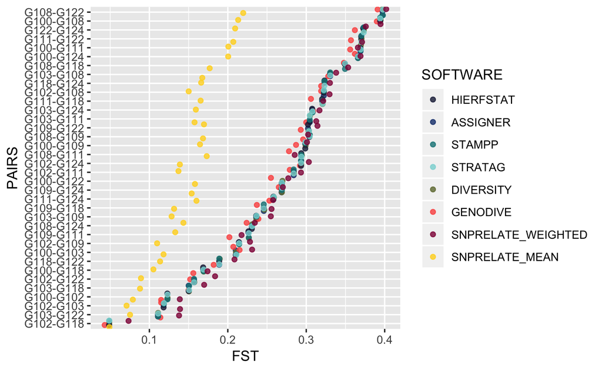

```r
plot.fst <- fst.summary %>%
  tidyr::unite(data = ., col = PAIRS, POP1, POP2, sep = "-") %>%
  tidyr::gather(data = ., key = SOFTWARE, value = FST, -PAIRS) %>%
  dplyr::mutate(
    SOFTWARE = factor(
      x = SOFTWARE,
      levels = c("HIERFSTAT", "ASSIGNER", "STAMPP", "STRATAG", "DIVERSITY", "GENODIVE", "SNPRELATE_WEIGHTED", "SNPRELATE_MEAN"), ordered = TRUE))

pairs.levels <- dplyr::group_by(plot.fst, PAIRS) %>%
  dplyr::summarise(FST = mean(FST, na.rm = TRUE)) %>%
  dplyr::arrange(FST) %$%
  PAIRS
under.the.sea.palette <- c("#1C2344", "#163D7D", "#118386", "#89D6D6", "#6E783D", "#FC564F", "#901546", "#FFD521")#, "#010101")
plot.fst %<>%
  dplyr::mutate(PAIRS = factor(x = PAIRS, levels = pairs.levels, ordered = TRUE)) %>%
  ggplot2::ggplot(data = ., ggplot2::aes(x = FST, y = PAIRS, colour = SOFTWARE)) +
  ggplot2::geom_jitter(alpha = 0.8) +
  ggplot2::scale_colour_manual(values = under.the.sea.palette)
```

## Simulated datasets

### sim_01: high Fst

**Generate a summary tibble:**

```r
fst.summary.sim01<- suppressWarnings(
  assigner.sim01.fst %>%
    dplyr::full_join(diversity.sim01.fst, by = c("POP1", "POP2")) %>%
    dplyr::full_join(genodive.sim01.fst, by = c("POP1", "POP2")) %>%
    dplyr::full_join(hierfstat.sim01.fst, by = c("POP1", "POP2")) %>%
    dplyr::full_join(stampp.sim01.fst, by = c("POP1", "POP2")) %>%
    dplyr::full_join(stratag.sim01.fst, by = c("POP1", "POP2")) %>%
    dplyr::full_join(snprelate.sim01.fst, by = c("POP1", "POP2")) %>%
    dplyr::mutate_if(.tbl = ., .predicate = is.numeric, .funs = round, 4)
)
fst.summary.sim01
```

| POP1 | POP2 | ASSIGNER_SIM01 | DIVERSITY_SIM01 | GENODIVE_SIM01 | HIERFSTAT_SIM01 | STAMPP_SIM01 | STRATAG_SIM01 | SNPRELATE_MEAN_SIM01 | SNPRELATE_WEIGHTED_SIM01 |
| --- | --- | --- | --- | --- | --- | --- | --- | --- | --- |
| POP_1 | POP_2 | 0.5140 | 0.5140 | 0.5140 | 0.5140 | 0.5140 | 0.5140 | 0.3141 | 0.5140 |
| POP_1 | POP_3 | 0.4811 | 0.4811 | 0.4811 | 0.4811 | 0.4811 | 0.4811 | 0.3069 | 0.4811 |
| POP_1 | POP_4 | 0.4245 | 0.4245 | 0.4245 | 0.4245 | 0.4245 | 0.4245 | 0.2842 | 0.4244 |
| POP_1 | POP_5 | 0.4098 | 0.4098 | 0.4098 | 0.4098 | 0.4098 | 0.4098 | 0.2664 | 0.4098 |
| POP_2 | POP_3 | 0.4118 | 0.4118 | 0.4118 | 0.4118 | 0.4118 | 0.4118 | 0.2747 | 0.4119 |
| POP_2 | POP_4 | 0.3696 | 0.3696 | 0.3696 | 0.3696 | 0.3696 | 0.3696 | 0.2516 | 0.3696 |
| POP_2 | POP_5 | 0.3598 | 0.3598 | 0.3598 | 0.3598 | 0.3598 | 0.3598 | 0.2396 | 0.3599 |
| POP_3 | POP_4 | 0.3555 | 0.3555 | 0.3555 | 0.3555 | 0.3555 | 0.3555 | 0.2519 | 0.3555 |
| POP_3 | POP_5 | 0.3413 | 0.3413 | 0.3413 | 0.3413 | 0.3413 | 0.3413 | 0.2363 | 0.3413 |
| POP_4 | POP_5 | 0.3006 | 0.3006 | 0.3006 | 0.3006 | 0.3006 | 0.3006 | 0.2122 | 0.3006 |

**Generate the correlation tibble:**

```r
fst.corr.tibble.sim01 <- round(cor(x = dplyr::select(fst.summary.sim01, -POP1, -POP2)), 6) %>%
 radiator::distance2tibble(
  x = .,
  na.diag = TRUE,
  relative = FALSE,
  pop.levels = c("HIERFSTAT_SIM01", "STRATAG_SIM01", "ASSIGNER_SIM01", "DIVERSITY_SIM01", "STAMPP_SIM01", "GENODIVE_SIM01", "SNPRELATE_MEAN_SIM01", "SNPRELATE_WEIGHTED_SIM01")) %>%
  magrittr::set_colnames(x = ., value = c("ID1", "ID2", "CORRELATION_SIM01")) %>%
  dplyr::arrange(dplyr::desc(CORRELATION_SIM01))
fst.corr.tibble.sim01
```

| ID1 | ID2 | CORRELATION_SIM01 |
| --- | --- | --- |
| ASSIGNER_SIM01 | DIVERSITY_SIM01 | 1.000000 |
| ASSIGNER_SIM01 | GENODIVE_SIM01 | 1.000000 |
| DIVERSITY_SIM01 | GENODIVE_SIM01 | 1.000000 |
| ASSIGNER_SIM01 | HIERFSTAT_SIM01 | 1.000000 |
| DIVERSITY_SIM01 | HIERFSTAT_SIM01 | 1.000000 |
| GENODIVE_SIM01 | HIERFSTAT_SIM01 | 1.000000 |
| ASSIGNER_SIM01 | STAMPP_SIM01 | 1.000000 |
| DIVERSITY_SIM01 | STAMPP_SIM01 | 1.000000 |
| GENODIVE_SIM01 | STAMPP_SIM01 | 1.000000 |
| HIERFSTAT_SIM01 | STAMPP_SIM01 | 1.000000 |

[output cut: 18 more lines]

### sim_02: low Fst

**Generate a summary tibble:**

```r
fst.summary.sim02<- suppressWarnings(
  assigner.sim02.fst %>%
    dplyr::full_join(diversity.sim02.fst, by = c("POP1", "POP2")) %>%
    dplyr::full_join(genodive.sim02.fst, by = c("POP1", "POP2")) %>%
    dplyr::full_join(hierfstat.sim02.fst, by = c("POP1", "POP2")) %>%
    dplyr::full_join(stampp.sim02.fst, by = c("POP1", "POP2")) %>%
    dplyr::full_join(stratag.sim02.fst, by = c("POP1", "POP2")) %>%
    dplyr::full_join(snprelate.sim02.fst, by = c("POP1", "POP2")) %>%
    dplyr::mutate_if(.tbl = ., .predicate = is.numeric, .funs = round, 4)
)
fst.summary.sim02
```

| POP1 | POP2 | ASSIGNER_SIM02 | DIVERSITY_SIM02 | GENODIVE_SIM02 | HIERFSTAT_SIM02 | STAMPP_SIM02 | STRATAG_SIM02 | SNPRELATE_MEAN_SIM02 | SNPRELATE_WEIGHTED_SIM02 |
| --- | --- | --- | --- | --- | --- | --- | --- | --- | --- |
| POP_1 | POP_2 | 0.0010 | 0.0010 | 0.0010 | 0.0010 | 0.0010 | 0.0010 | 0.0010 | 0.0010 |
| POP_1 | POP_3 | 0.0032 | 0.0032 | 0.0032 | 0.0032 | 0.0032 | 0.0032 | 0.0019 | 0.0031 |
| POP_1 | POP_4 | 0.0021 | 0.0021 | 0.0021 | 0.0021 | 0.0021 | 0.0021 | 0.0017 | 0.0019 |
| POP_1 | POP_5 | 0.0022 | 0.0022 | 0.0022 | 0.0022 | 0.0022 | 0.0022 | 0.0010 | 0.0021 |
| POP_2 | POP_3 | 0.0001 | 0.0001 | 0.0001 | 0.0001 | 0.0001 | 0.0001 | 0.0005 | 0.0002 |
| POP_2 | POP_4 | 0.0002 | 0.0002 | 0.0002 | 0.0002 | 0.0002 | 0.0002 | 0.0007 | 0.0002 |
| POP_2 | POP_5 | 0.0005 | 0.0005 | 0.0005 | 0.0005 | 0.0005 | 0.0005 | 0.0010 | 0.0005 |
| POP_3 | POP_4 | 0.0000 | -0.0006 | -0.0006 | -0.0006 | -0.0006 | -0.0006 | -0.0005 | -0.0007 |
| POP_3 | POP_5 | 0.0028 | 0.0028 | 0.0028 | 0.0028 | 0.0028 | 0.0028 | 0.0016 | 0.0027 |
| POP_4 | POP_5 | 0.0017 | 0.0017 | 0.0017 | 0.0017 | 0.0017 | 0.0017 | 0.0005 | 0.0015 |

**Generate the correlation tibble:**

```r
fst.corr.tibble.sim02 <- round(cor(x = dplyr::select(fst.summary.sim02, -POP1, -POP2)), 6) %>%
 radiator::distance2tibble(
  x = .,
  na.diag = TRUE,
  relative = FALSE,
  pop.levels = c("HIERFSTAT_SIM02", "STRATAG_SIM02", "ASSIGNER_SIM02", "DIVERSITY_SIM02", "STAMPP_SIM02", "GENODIVE_SIM02", "SNPRELATE_MEAN_SIM02", "SNPRELATE_WEIGHTED_SIM02")) %>%
  magrittr::set_colnames(x = ., value = c("ID1", "ID2", "CORRELATION_SIM02")) %>%
  dplyr::arrange(dplyr::desc(CORRELATION_SIM02))
fst.corr.tibble.sim02
```

| ID1 | ID2 | CORRELATION_SIM02 |
| --- | --- | --- |
| DIVERSITY_SIM02 | GENODIVE_SIM02 | 1.000000 |
| DIVERSITY_SIM02 | HIERFSTAT_SIM02 | 1.000000 |
| GENODIVE_SIM02 | HIERFSTAT_SIM02 | 1.000000 |
| DIVERSITY_SIM02 | STAMPP_SIM02 | 1.000000 |
| GENODIVE_SIM02 | STAMPP_SIM02 | 1.000000 |
| HIERFSTAT_SIM02 | STAMPP_SIM02 | 1.000000 |
| DIVERSITY_SIM02 | STRATAG_SIM02 | 1.000000 |
| GENODIVE_SIM02 | STRATAG_SIM02 | 1.000000 |
| HIERFSTAT_SIM02 | STRATAG_SIM02 | 1.000000 |
| STAMPP_SIM02 | STRATAG_SIM02 | 1.000000 |

[output cut: 18 more lines]

# Table of features

The table timing was produced using the empirical dataset.

```r
summary.table <- readr::read_tsv(file = "fst_comparisons_packages_features.tsv", col_types = readr::cols(.default = readr::col_character()))
knitr::kable(summary.table) %>%
  kableExtra::kable_styling(bootstrap_options = c("striped", "hover", "condensed", "responsive"), full_width = FALSE)
```

| FEATURES | HIERFSTAT | STRATAG | ASSIGNER | DIVERSITY | STAMPP | GENODIVE | SNPRELATE | VCFtools |
| --- | --- | --- | --- | --- | --- | --- | --- | --- |
| Function | pairwise.WCfst | popStructTest | fst_WC84 | diffCalc | stamppFst | F_st | snpgdsFst | --weir-fst-pop |
| W&C 1984 Fst | yes | yes | yes | yes | yes | yes | yes | yes |
| Language | R | R, C | R | R, C++ | R | Objective-C | R, C++ | Perl, C++ |
| Data | object | object | both | file | object | file | object | file |
| Format | hierfstat | gtypes | several | genepop | genlight | several | SNPRelate GDS | VCF |
| Polymorphic markers | yes | ? | yes | ? | yes | ? | yes | yes |
| Tailor common markers | yes | ? | yes | ? | yes | ? | ? | yes |
| Output number of markers | no | no | yes | no | no | no | yes | no |
| Global fst | no | yes | yes | yes | no | no | yes | yes |
| Pairwise fst | yes | yes | yes | yes | yes | yes | no* | no |
| Bootstrap individuals | no | no | no | yes | no | no | no | no |
| Boostrap loci | no | yes | yes | yes | yes | yes | no | no |
| CI | no | no | yes | yes | yes | no | no | no |
| P-Value | no | yes | no | no | yes | yes | no | no |
| Locus pairwise | no | no | no | yes | no | no | no | no |
| Figures | no | no | yes | no | no | no | no | no |
| Tibble | no | yes | yes | no | no | no | no | no |
| Full upper and lower matrix | yes | no | yes | no | no | yes | yes | no |
| Upper matrix | no | no | yes | no | no | no | no | no |
| Lower matrix | no | yes | yes | yes | yes | no | no | no |
| Combo matrix (Fst + stats) | no | yes | yes | no | no | no | no | no |
| Fst markers | yes | no | yes | yes | no | no | yes | yes |
| Fis | yes | no | yes | yes | no | no | no | no |
| Write | no | no | yes | yes | no | no | no | yes |
| Parallelize | no | yes | yes | yes | yes* | yes | yes | yes |
| OS (linux, macOS, windows) | all | all | all | all | all | macOS | all | all |
| Impacted by missingness | no | yes | no | yes | yes | yes | yes | yes |
| Timing (sec) | 1234 | 657 | 49 | 43 | 39 | 3 | 0.245 | 2* |

*Note:*

- VCFtools: we used only 2 populations and timing is inside VCFtools only, it doesn’t account for manipulations of output.
- SNPRelate: No out-of-the-box pairwise Fst analysis, but very quick solution is proposed in this vignette.

# Conclusion

You could go and look at the 36 pairwise comparisons, but the end of the story is very simple:

In the absence of missing data, because overall Fst values are similar, in the end, it’s worth looking at:

- **speed**: if this is an issue for you (e.g. if running multiple simulations, assignment analysis, etc).
- **features**: lots of differences between packages/software.

*Please let me know if I did something wrong or forgot to mention an interesting feature of your favorite package.*